# chiSquareAnalysis

April 10th, 2025

## Chi Square Test

Start by defining some colours.

```r
colours <- c("#FF9580","#F2FAA6", "#B8B3EA")
```

### Load in the data

Use the function `read.csv` to load the in the comic book data set. Update to the correct directory structure.

```r
comicData <- read.csv("/users/Pablo/downloads/comic_characters.csv")
```

Look at the variables available to you in the data set.

```r
str(comicData)
```

```
## 'data.frame':    21144 obs. of  12 variables:
##  $ Id            : int  0 1 2 3 4 5 6 7 8 9 ...
##  $ Name          : chr  "Dave Finn" "Katherine Power" "John Malone" "Samuel Bradley, Jr." ...
##  $ Identity      : chr  "Secret" "Secret" "Secret" "Public" ...
##  $ Alignment     : chr  "Good" "Good" "Bad" "Bad" ...
##  $ Eyes          : chr  "Blue" "Blue" "Blue" "Brown" ...
##  $ Hair          : chr  "Black" "Red" "White" "Brown" ...
##  $ Sex           : chr  "Male" "Female" "Male" "Male" ...
##  $ Alive         : chr  "Yes" "Yes" "Yes" "No" ...
##  $ Appearances   : int  1 106 15 19 28 3 7 350 1 3 ...
##  $ First_appeared: chr  "2002, July" "1984, August" "1985, January" "2004, March" ...
##  $ Planet        : chr  "Earth-616" "Earth-616" "New Earth" "New Earth" ...
##  $ Universe      : chr  "Marvel" "Marvel" "DC" "DC" ...
```

#Research Question?

Is there a relationship between a comic book character’s identity and whether they are alive or dead?

#Null Hypothesis (H₀):

There is no association between a character’s identity and their alive status.

#Alternative Hypothesis (H₁):

There is an association between a character’s identity and their alive status.

getExpectedTable calculates the expected values from the frequency table returned by `table`. This function should work for any comparison you make (you could use any two categorical variables)

```r
getExpectedTable <- function(f){
  rowTotal <- apply(f, 1, sum)
  columTotal <- apply(f, 2, sum)
  tableTotal <- sum(f)

  # Matrix multiplication in R
  Expected <- (rowTotal %*% t(columTotal))/tableTotal
  return(Expected)
}
```

```r
xFreq <- table(comicData$Alive, comicData$Identity)
xFreq
```

```
##
##       Known to Authorities Non-dual Public Secret Unknown
##   No                     2      498   1981   2610       3
##   Yes                   20     1574   6604   7842      10
```

- ‘Secret’ and ‘Public’ variables have the most observations.
- The variables ‘Unknown’ and ‘Known to Authorities’ have significantly less observations than the others.

```r
expected <- getExpectedTable(xFreq)
expected
```

```
##      Known to Authorities Non-dual   Public  Secret  Unknown
## [1,]             5.300227  499.185 2068.293 2518.09 3.131952
## [2,]            16.699773 1572.815 6516.707 7933.91 9.868048
```

```r
chiSqP <- sum((((xFreq - expected)**2)) / expected)
chiSqP
```

```
## [1] 11.99116
```

```r
p <- pchisq(chiSqP, df = 4, lower.tail = FALSE)
p
```

```
## [1] 0.01741715
```

```r
p > 0.05
```

```
## [1] FALSE
```

#Now, let’s perform permutation test.

```r
getShuffledCounts <- function(columTotal, rowTotal, tableTotal) {
  AandB <- c(rep(1, columTotal[1]), rep(0, columTotal[2]))

  nA <- rowTotal[1]
  nB <- rowTotal[2]
  nC <- rowTotal[3]
  nD <- rowTotal[4]
  nE <- rowTotal[5]

  N <- tableTotal

  chiSquareP <-NULL

  idxA <- sample(1:N, nA, replace = FALSE)
  remaining <- setdiff(1:N, idxA)
  idxB <- sample(remaining, nB, replace = FALSE)
  remaining <- setdiff(remaining, idxB)
  idxC <- sample(remaining, nC, replace = FALSE)
  remaining <- setdiff(remaining, idxC)
  idxD <- sample(remaining, nD, replace = FALSE)
  idxE <- setdiff(remaining, idxD)

  knownAuth <- c(sum(AandB[idxA]), nA - sum(AandB[idxA]))
  nonDual   <- c(sum(AandB[idxB]), nB - sum(AandB[idxB]))
  public    <- c(sum(AandB[idxC]), nC - sum(AandB[idxC]))
  secret    <- c(sum(AandB[idxD]), nD - sum(AandB[idxD]))
  unknown   <- c(sum(AandB[idxE]), nE - sum(AandB[idxE]))

  # Combine into matrix
  theMatrix <- rbind(knownAuth, nonDual, public, secret, unknown)
  colnames(theMatrix) <- c("Dead", "Alive")
  rownames(theMatrix) <- names(rowTotal)

  return(theMatrix)
}
```

```r
set.seed(123)
chiTemp <- NULL
for (i in 1:2000){
  theMatrix <- getShuffledCounts(columTotal = rowSums(xFreq), rowTotal = colSums(xFreq), tableTotal = sum(xFreq))
  chiTemp[i] <- sum((t(theMatrix) - expected) ** 2 / expected)
}
```

```r
permutP <- mean(chiTemp > chiSqP)
permutP
```

```
## [1] 0.022
```

#Let’s visualize our Chi Square Distribution.

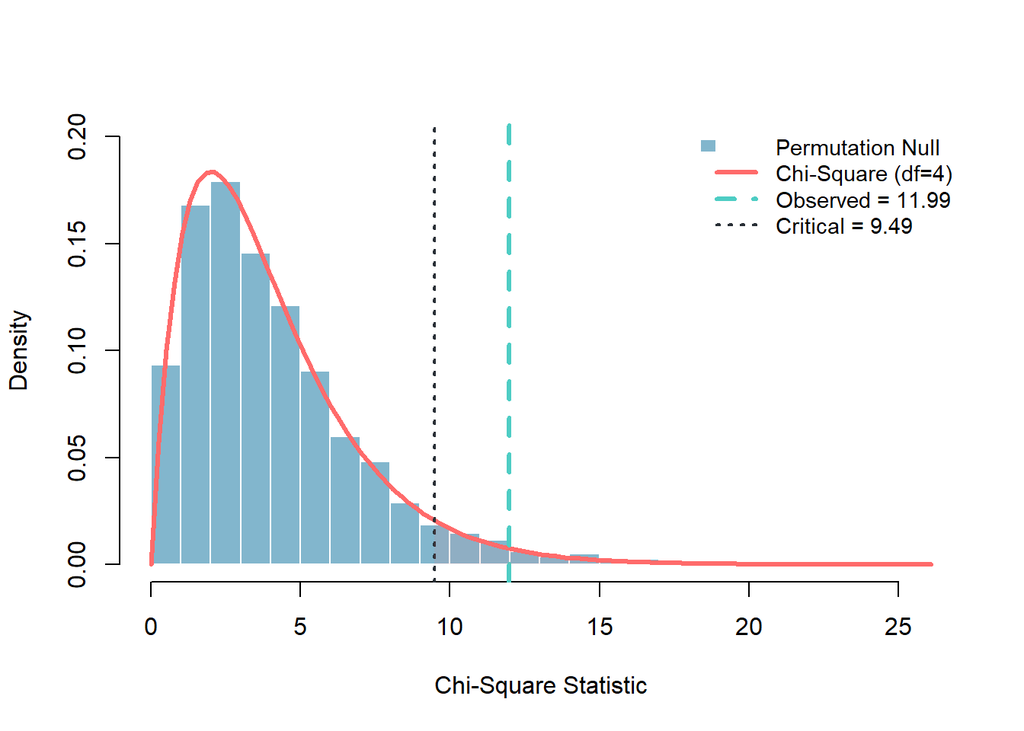

```r
# Set colors
colors <- c("#2E86AB", "#FF6B6B", "#4ECDC4", "#292F36")

hist(chiTemp,
     breaks = 30,
     freq = FALSE,
     col = adjustcolor(colors[1], alpha.f = 0.6),
     border = "white",
     main = "",  # Removed title
     xlab = "Chi-Square Statistic",
     ylab = "Density",
     xlim = c(0, max(chiTemp) + 5),
     ylim = c(0, 0.2))

curve(dchisq(x, df = 4), col = colors[2], lwd = 3, add = TRUE)  # Chi-square curve
abline(v = qchisq(0.95, df = 4), col = colors[4], lwd = 2, lty = 3)  # Critical line
abline(v = chiSqP, col = colors[3], lwd = 3, lty = 2)  # Observed stat

legend("topright",
       legend = c("Permutation Null",
                  "Chi-Square (df=4)",
                  paste("Observed =", round(chiSqP, 2)),
                  paste("Critical =", round(qchisq(0.95, df=4), 2))),
       fill = c(adjustcolor(colors[1], alpha.f=0.6), NA, NA, NA),
       border = c("white", NA, NA, NA),
       lty = c(NA, 1, 2, 3),
       col = c(NA, colors[2], colors[3], colors[4]),
       lwd = c(NA, 3, 3, 2),
       bty = "n",
       cex = 0.9)

polygon(c(qchisq(0.95, df=4), seq(qchisq(0.95, df=4), 25, length=100), 25),
        c(0, dchisq(seq(qchisq(0.95, df=4), 25, length=100), df=4), 0),
        col=adjustcolor(colors[2], alpha.f=0.1), border=NA)
```

#Conclusion The permutation test gives a p-value of 0.022 (< 0.05), so we reject the null hypothesis. There is statistically significant evidence that a comic character’s identity status is linked to their survival (Alive/Dead). The data supports the alternative hypothesis: identity and survival are associated.